# Agent-Based Models and Sustainability

Ernesto Carrella

May 22, 2018

## Why bother ?

- Details
- Model flexibility is fundamental for good policy analysis
- Computational models are more flexible

## An academic example

- “Marine reserves solve an important bycatch problem in fisheries”, PNAS, 2017
- Assume that:
  - There are only 2 species of fish
  - Sea soup distribution
  - Manager perfectly observes biomass
  - Fishers exploit optimally
- Then:
  - We can prove mathematically that protected areas are better than constant escapement rules

## Questions that actually get asked

- In a 81-species complex, who wins and loses after a price shock?
- How to police a segment of the fishery given that another set of boats cannot be regulated?
- How to rotate protected areas in a “fair” manner?
- What happens to fishing efficiency once we switch from one policy to another?

## Not an easy fix

- Curse of dimensionality : finding the optimal fishing path is often mathematically intractable
- Deep uncertainty

## Deep uncertainty

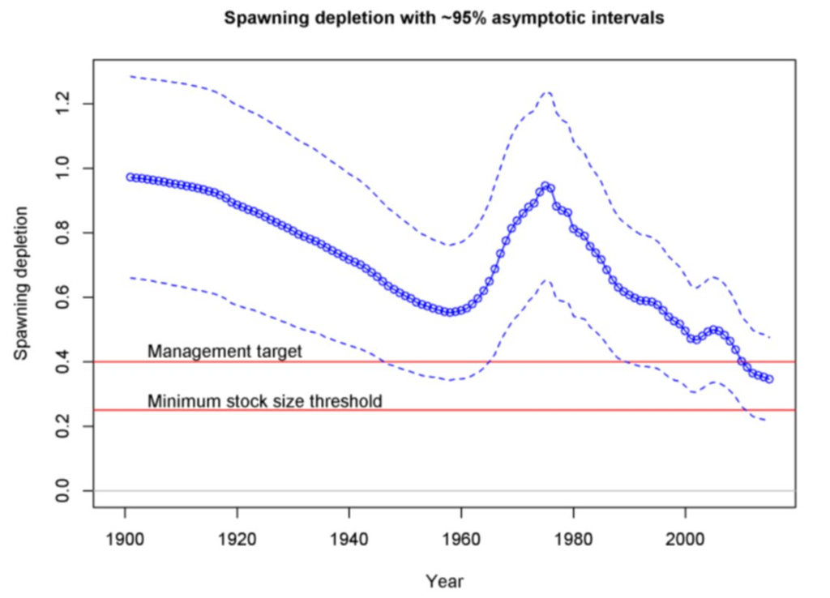

## Heuristic managers

- Carruthers et al (2014)

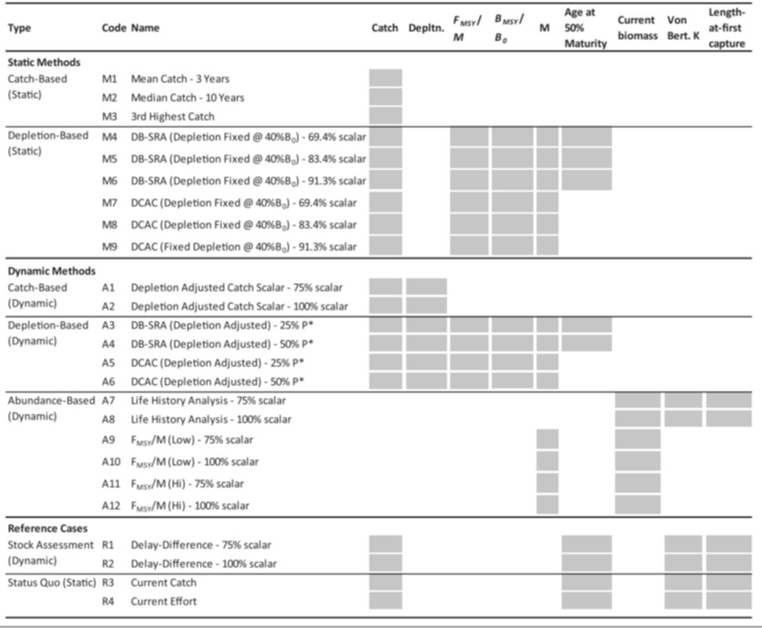

## Aggregate Uncertainty - Individual Observations

- Logbook data
- Fish tickets
- Satellite data
- Biological Indicators

## But the fisher, being unaware of these scientific facts, fish anyway.

- Bastardie et al (2014)

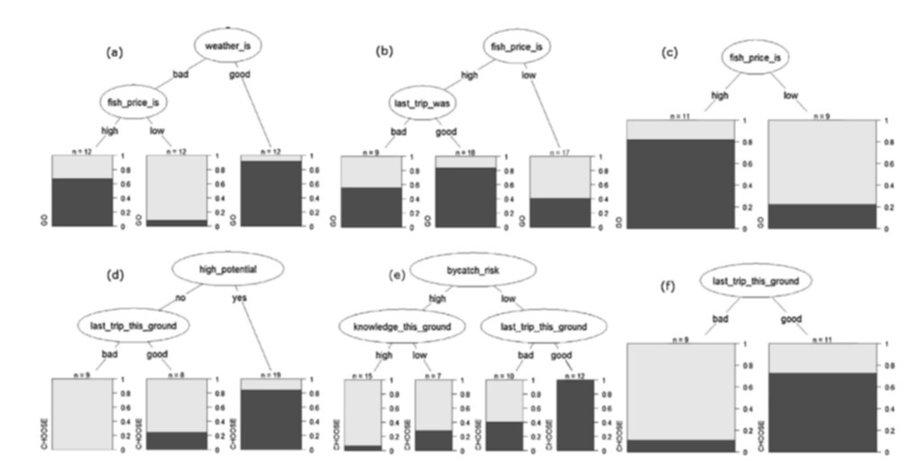

## Use them to fit a model

- Bastardie et al(2017)

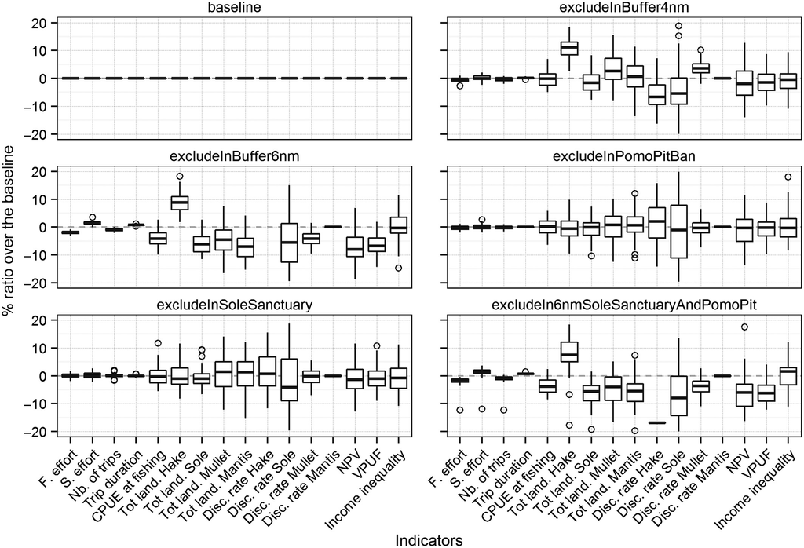

## Spatial Knowledge

- Cenek & Fanklin (2017)

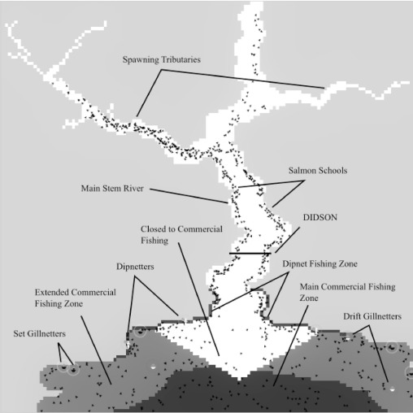

## Biological Knowledge

- Saul (2014)

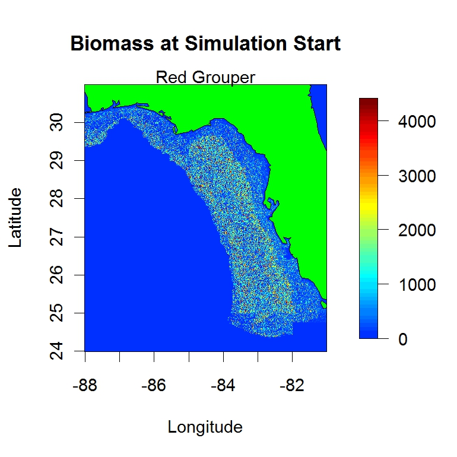

- Cabral et al (working)

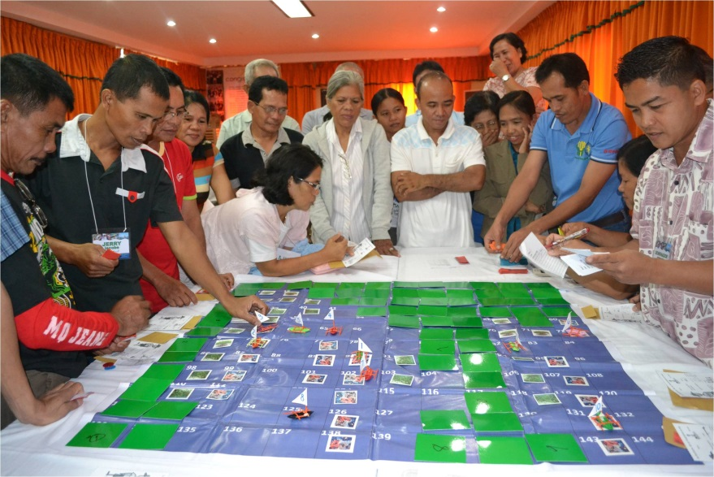

## ABM as data-analysis and aggregators

- Agent-Based models combine
  1. Individual-level data
  2. Spatial knowledge
  3. Known feedback rules
- Produce insights and knowledge

## Discussion Slide

- Objectives
  - Policy Planning
  - Hypothesis Testing
  - Participatory Modelling
- Advantages
  - Heterogeneity
  - Availability of individual data
  - Spatial information
  - Environmental feedbacks
  - Evolving/Adapting behaviour